# Banking Capstone - Data Wrangling and Stastical Analysis

Demetri Lee

April 1, 2019

## Working to predict the success of bank marketing

I’m working on predicting the success of telemarketing calls for a bank that’s selling long-term deposits. A Portuguese retail bank was addressed, with data collected from 2008 to 2013, thus including the effects of the recent financial crisis of 2008. With 21 features available for analysis, I hope to derive knowledge for a model that would confirm how to better focus resources towards clients with a high chance of agreeing to registering for extra banking services.

The [data set](https://archive.ics.uci.edu/ml/datasets/Bank+Marketing) can be found at an archive for Marchine Learning.

### This is the data dictionary provided by the respective retail bank:

**Bank client data**

1. age: numeric
2. job: type of job (categorical: admin, blue-collar, entrepreneur, housemaid, management, retired, self-employed, services, student, technician, unemployed, unknown)
3. marital: marital status (categorical: divorced, married, single, unknown; note: ‘divorced’ means divorced or widowed)
4. education: (categorical: basic.4y, basic.6y, basic.9y, high.school, illiterate, professional.course, university.degree, unknown)
5. default: has credit in default? (categorical: no, yes, unknown)
6. housing: has housing loan? (categorical: no, yes, unknown)
7. loan: has personal loan? (categorical: no, yes, unknown)

**Related with the last contact of the current campaign**

8. contact: contact communication type (categorical: cellular, telephone)
9. month: last contact month of year (categorical: jan’, ‘feb’, ‘mar’, …, ‘nov’, ‘dec’)
10. day_of_week: last contact day of the week (categorical: mon, tue, wed, thu, fri)
11. duration: last contact duration, in seconds (numeric). Important note: this attribute highly affects the output target (e.g., if duration=0 then y=‘no’). Yet, the duration is not known before a call is performed. Also, after the end of the call y is obviously known. Thus, this input should only be included for benchmark purposes and should be discarded if the intention is to have a realistic predictive model.

**Other attributes**

12. campaign: number of contacts performed during this campaign and for this client (numeric, includes last contact)
13. pdays: number of days that passed by after the client was last contacted from a previous campaign (numeric; 999 means client was not previously contacted)
14. previous: number of contacts performed before this campaign and for this client (numeric)
15. poutcome: outcome of the previous marketing campaign (categorical: failure, nonexistent, success)

**Social and economic context attributes**

16. emp.var.rate: employment variation rate - quarterly indicator (numeric)
17. cons.price.idx: consumer price index - monthly indicator (numeric)
18. cons.conf.idx: consumer confidence index - monthly indicator (numeric)
19. euribor3m: euribor 3 month rate - daily indicator (numeric)
20. nr.employed: number of employees - quarterly indicator (numeric)

**Output variable (desired target)**

21. y: has the client subscribed a term deposit? (binary: yes, no)

### Data Preparation

Let’s start by reading in the dataset with values delimited by semi-colons along with designated column types as indicated by the data dictionary.

```r
bankfull <- read_delim(file = "bank-additional-full.csv", delim = ";", col_types = "ifffffffffiiiifdddddf")

summary(bankfull)
```

```
##       age                 job            marital
##  Min.   :17.00   admin.     :10422   married :24928
##  1st Qu.:32.00   blue-collar: 9254   single  :11568
##  Median :38.00   technician : 6743   divorced: 4612
##  Mean   :40.02   services   : 3969   unknown :   80
##  3rd Qu.:47.00   management : 2924
##  Max.   :98.00   retired    : 1720
##                  (Other)    : 6156
##                education        default         housing
##  university.degree  :12168   no     :32588   no     :18622
##  high.school        : 9515   unknown: 8597   yes    :21576
##  basic.9y           : 6045   yes    :    3   unknown:  990
##  professional.course: 5243
##  basic.4y           : 4176
##  basic.6y           : 2292
##  (Other)            : 1749
##       loan            contact          month       day_of_week
##  no     :33950   telephone:15044   may    :13769   mon:8514
##  yes    : 6248   cellular :26144   jul    : 7174   tue:8090
##  unknown:  990                     aug    : 6178   wed:8134
##                                    jun    : 5318   thu:8623
##                                    nov    : 4101   fri:7827
##                                    apr    : 2632
##                                    (Other): 2016
##     duration         campaign          pdays          previous
##  Min.   :   0.0   Min.   : 1.000   Min.   :  0.0   Min.   :0.000
##  1st Qu.: 102.0   1st Qu.: 1.000   1st Qu.:999.0   1st Qu.:0.000
##  Median : 180.0   Median : 2.000   Median :999.0   Median :0.000
##  Mean   : 258.3   Mean   : 2.568   Mean   :962.5   Mean   :0.173
##  3rd Qu.: 319.0   3rd Qu.: 3.000   3rd Qu.:999.0   3rd Qu.:0.000
##  Max.   :4918.0   Max.   :56.000   Max.   :999.0   Max.   :7.000
##
##         poutcome      emp.var.rate      cons.price.idx  cons.conf.idx
##  nonexistent:35563   Min.   :-3.40000   Min.   :92.20   Min.   :-50.8
##  failure    : 4252   1st Qu.:-1.80000   1st Qu.:93.08   1st Qu.:-42.7
##  success    : 1373   Median : 1.10000   Median :93.75   Median :-41.8
##                      Mean   : 0.08189   Mean   :93.58   Mean   :-40.5
##                      3rd Qu.: 1.40000   3rd Qu.:93.99   3rd Qu.:-36.4
##                      Max.   : 1.40000   Max.   :94.77   Max.   :-26.9
##
##    euribor3m      nr.employed     y
##  Min.   :0.634   Min.   :4964   no :36548
##  1st Qu.:1.344   1st Qu.:5099   yes: 4640
##  Median :4.857   Median :5191
##  Mean   :3.621   Mean   :5167
##  3rd Qu.:4.961   3rd Qu.:5228
##  Max.   :5.045   Max.   :5228
##
```

Let’s rename variables to be more descriptive and avoid use of periods.

The goal is to determine which factors lead to a subscription so it’s also best to rename the dependent variable `y` to `subscribed`, which is more descriptive.

```r
colnames(bankfull) <- c("age", "job", "marital", "edu_lvl", "cred_default", "mortgage", "loan",
                        "contact_typ", "month", "day_of_week", "duration_sec",
                        "contact_cnt", "days_passed", "prev_contact_cnt", "prev_outcome",
                        "emp_var_rate", "cons_price_idx", "cons_conf_idx", "euribor3m", "num_employed",
                        "subscribed")
```

Replace all periods (‘.’) in values for `job` and `edu_lvl`with underscores (’_’) for legibility.

```r
summary(bankfull$job) # job types before replacement
```

```
##     housemaid      services        admin.   blue-collar    technician
##          1060          3969         10422          9254          6743
##       retired    management    unemployed self-employed       unknown
##          1720          2924          1014          1421           330
##  entrepreneur       student
##          1456           875
```

```r
bankfull$job <- gsub("\\.", "", bankfull$job)
bankfull$job <- as.factor(bankfull$job)
summary(bankfull$job) # job types after replacement
```

```
##         admin   blue-collar  entrepreneur     housemaid    management
##         10422          9254          1456          1060          2924
##       retired self-employed      services       student    technician
##          1720          1421          3969           875          6743
##    unemployed       unknown
##          1014           330
```

```r
summary(bankfull$edu_lvl) # education levels before replacement
```

```
##            basic.4y         high.school            basic.6y
##                4176                9515                2292
##            basic.9y professional.course             unknown
##                6045                5243                1731
##   university.degree          illiterate
##               12168                  18
```

```r
bankfull$edu_lvl <- gsub("\\.", "_", bankfull$edu_lvl)
bankfull$edu_lvl <- as.factor(bankfull$edu_lvl)
summary(bankfull$edu_lvl) # education levels after replacement
```

```
##            basic_4y            basic_6y            basic_9y
##                4176                2292                6045
##         high_school          illiterate professional_course
##                9515                  18                5243
##   university_degree             unknown
##               12168                1731
```

Take a quick check of the dataset with glimpse.

```r
glimpse(bankfull)
```

```
## Observations: 41,188
## Variables: 21
## $ age              <int> 56, 57, 37, 40, 56, 45, 59, 41, 24, 25, 41, 2...
## $ job              <fct> housemaid, services, services, admin, service...
## $ marital          <fct> married, married, married, married, married, ...
## $ edu_lvl          <fct> basic_4y, high_school, high_school, basic_6y,...
## $ cred_default     <fct> no, unknown, no, no, no, unknown, no, unknown...
## $ mortgage         <fct> no, no, yes, no, no, no, no, no, yes, yes, no...
## $ loan             <fct> no, no, no, no, yes, no, no, no, no, no, no, ...
## $ contact_typ      <fct> telephone, telephone, telephone, telephone, t...
## $ month            <fct> may, may, may, may, may, may, may, may, may, ...
## $ day_of_week      <fct> mon, mon, mon, mon, mon, mon, mon, mon, mon, ...
## $ duration_sec     <int> 261, 149, 226, 151, 307, 198, 139, 217, 380, ...
## $ contact_cnt      <int> 1, 1, 1, 1, 1, 1, 1, 1, 1, 1, 1, 1, 1, 1, 1, ...
## $ days_passed      <int> 999, 999, 999, 999, 999, 999, 999, 999, 999, ...
## $ prev_contact_cnt <int> 0, 0, 0, 0, 0, 0, 0, 0, 0, 0, 0, 0, 0, 0, 0, ...
## $ prev_outcome     <fct> nonexistent, nonexistent, nonexistent, nonexi...
## $ emp_var_rate     <dbl> 1.1, 1.1, 1.1, 1.1, 1.1, 1.1, 1.1, 1.1, 1.1, ...
## $ cons_price_idx   <dbl> 93.994, 93.994, 93.994, 93.994, 93.994, 93.99...
## $ cons_conf_idx    <dbl> -36.4, -36.4, -36.4, -36.4, -36.4, -36.4, -36...
## $ euribor3m        <dbl> 4.857, 4.857, 4.857, 4.857, 4.857, 4.857, 4.8...
## $ num_employed     <dbl> 5191, 5191, 5191, 5191, 5191, 5191, 5191, 519...
## $ subscribed       <fct> no, no, no, no, no, no, no, no, no, no, no, n...
```

### Exploring Data with Plots

**Looking at Campaign results**

A cursory look at the `subscribe` variable will show most customers do not sign up for the extra service so the results are very skewed.

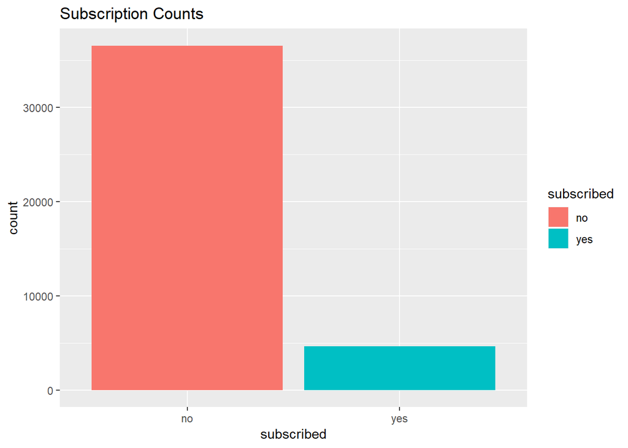

```r
ggplot(bankfull, aes(x = subscribed, fill = subscribed)) + geom_bar() +
  labs(title = "Subscription Counts")
```

The proportion of `no` to `yes` in a table:

```r
prop.table(table(bankfull$subscribed))
```

```
##
##        no       yes
## 0.8873458 0.1126542
```

When looking for clients that have subscribed to a previous campaign there are too many `nonexistent` values.

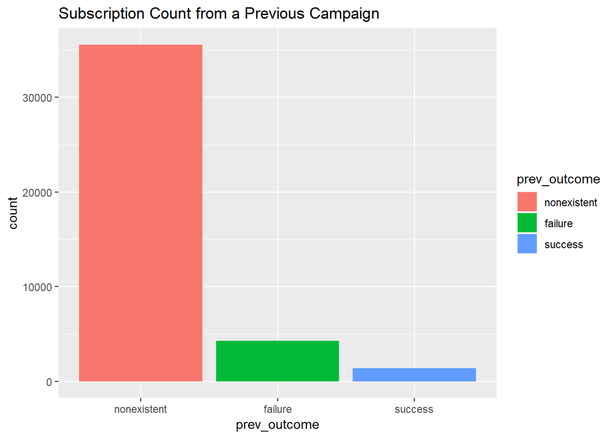

```r
ggplot(bankfull, aes(prev_outcome, fill=prev_outcome)) + geom_bar() +
  labs(title="Subscription Count from a Previous Campaign")
```

When comparing clients that subscribed to the previous campaign and the current campaign, the `nonexistent` values become distracting.

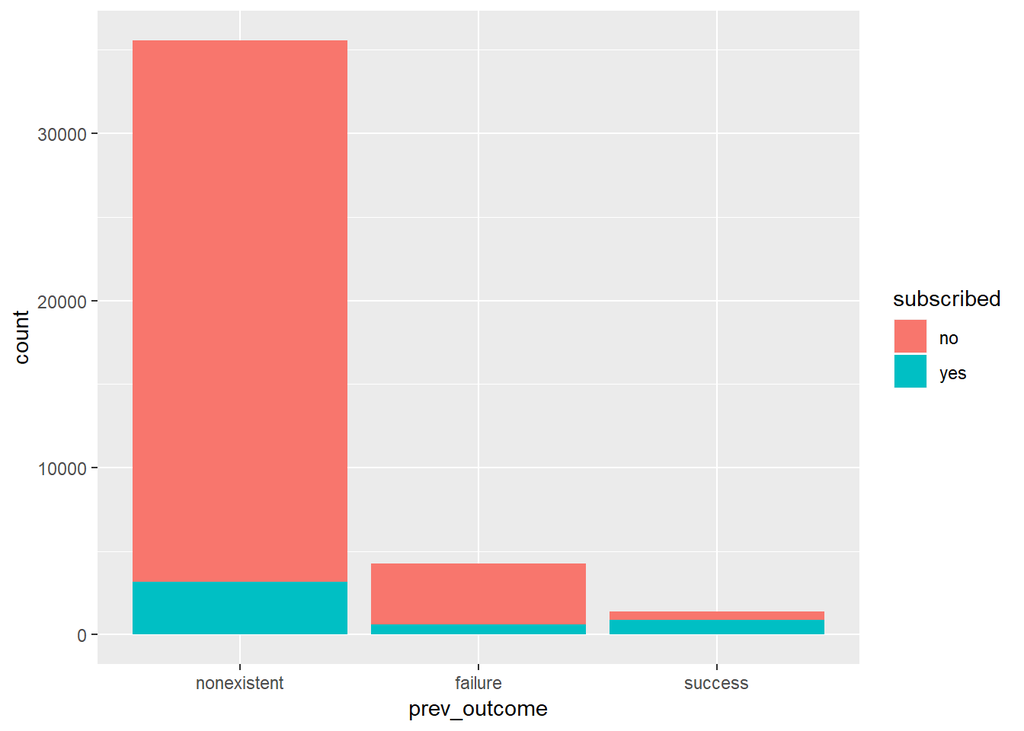

```r
ggplot(bankfull, aes(x=prev_outcome, fill=subscribed)) + geom_bar()
```

With the `nonexistent` values removed, notably more than half the clients can be seen as having subscribed again.

```r
ctable(bankfull$prev_outcome, bankfull$subscribed)
```

```
## Cross-Tabulation / Row Proportions
## Variables: prev_outcome * subscribed
## Data Frame: bankfull
##
## -------------- ------------ ---------------- --------------- -----------------
##                  subscribed               no             yes             Total
##   prev_outcome
##    nonexistent                32422 (91.17%)   3141 ( 8.83%)   35563 (100.00%)
##        failure                 3647 (85.77%)    605 (14.23%)    4252 (100.00%)
##        success                  479 (34.89%)    894 (65.11%)    1373 (100.00%)
##          Total                36548 (88.73%)   4640 (11.27%)   41188 (100.00%)
## -------------- ------------ ---------------- --------------- -----------------
```

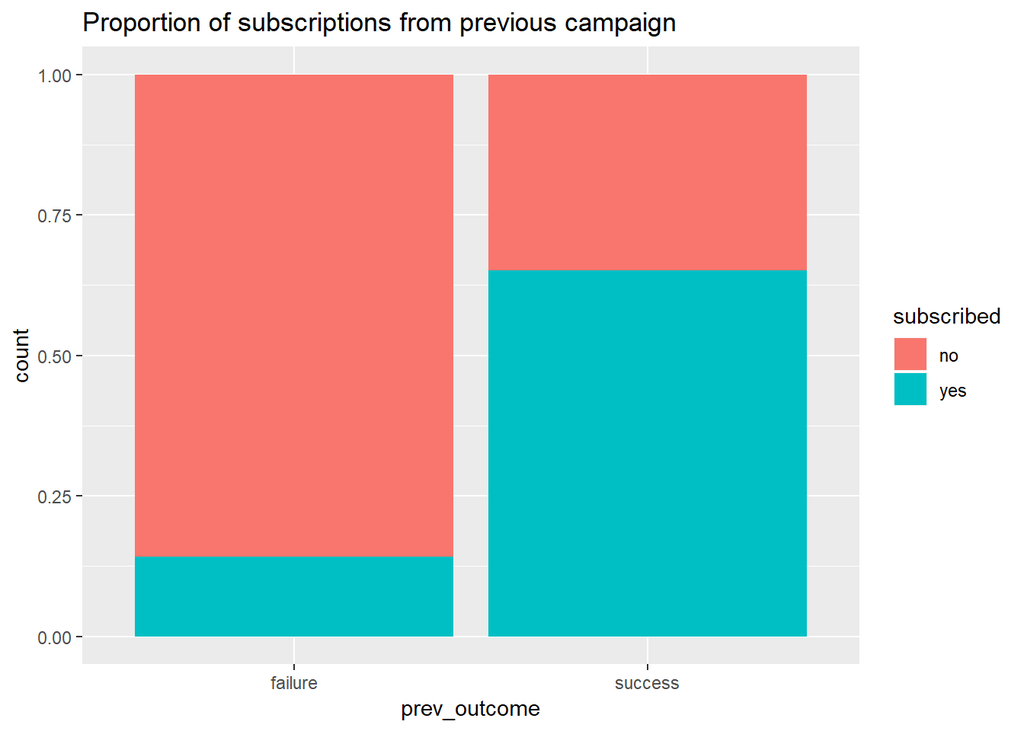

```r
bankfull_prev <- filter(bankfull, prev_outcome != "nonexistent")
ggplot(bankfull_prev, aes(x=prev_outcome, fill=subscribed)) +
  geom_bar(position="fill") +
  labs(title = "Proportion of subscriptions from previous campaign")
```

**Looking at Client Data**

Basic client data such as client age, marital status, education level or job type do not seem to show any strong trends.

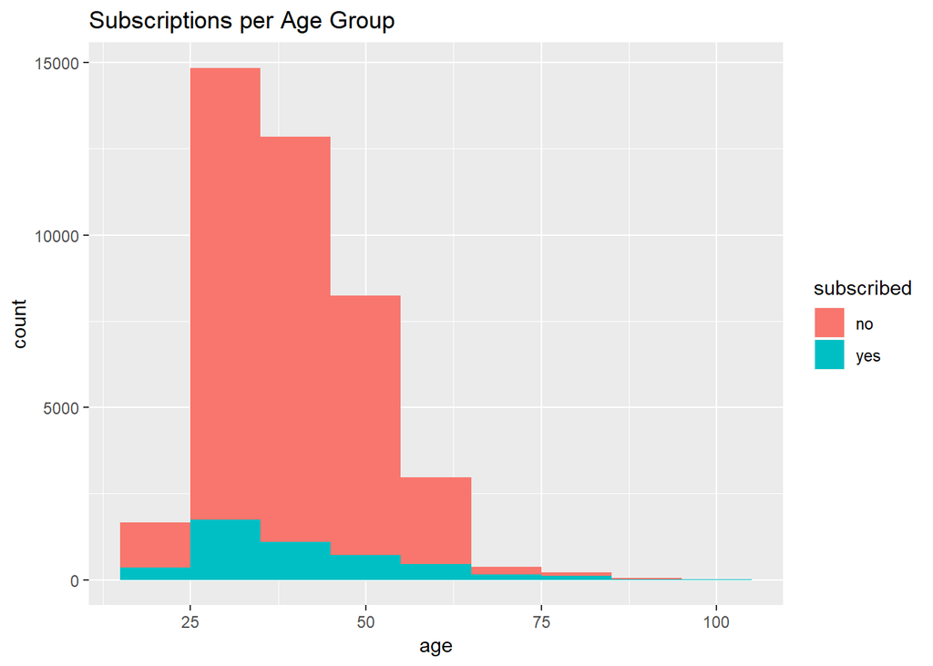

```r
ggplot(bankfull, aes(x = age, fill = subscribed)) +
  geom_histogram(binwidth=10) +
  labs(title = "Subscriptions per Age Group")
```

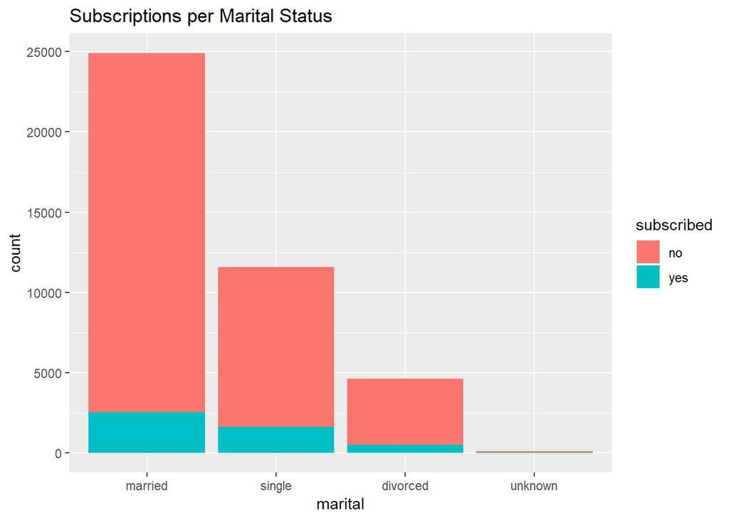

```r
ggplot(bankfull, aes(x = marital, fill = subscribed)) +
  geom_bar() +
  labs(title = "Subscriptions per Marital Status")
```

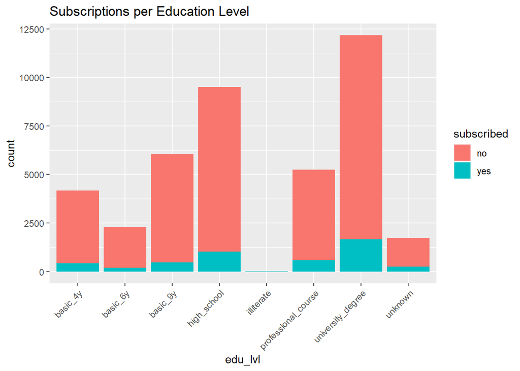

```r
ggplot(bankfull, aes(x = edu_lvl, fill = subscribed)) +
  geom_bar() +
  theme(axis.text.x = element_text(angle = 45, hjust = 1)) +
  labs(title = "Subscriptions per Education Level")
```

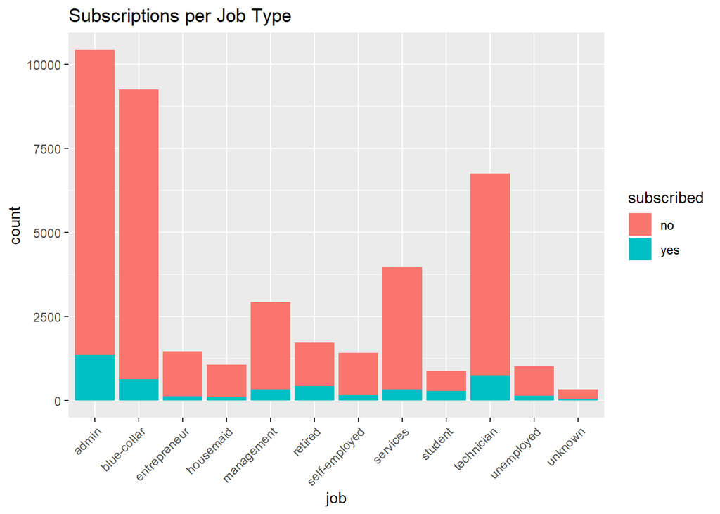

```r
ggplot(bankfull, aes(x = job, fill = subscribed)) +
  geom_bar() +
  theme(axis.text.x = element_text(angle = 45, hjust = 1)) +
  labs(title = "Subscriptions per Job Type")
```

Further review of clients’ financial records (credit in default, mortgage, or personal loan) also do not express any notable subscription trends.

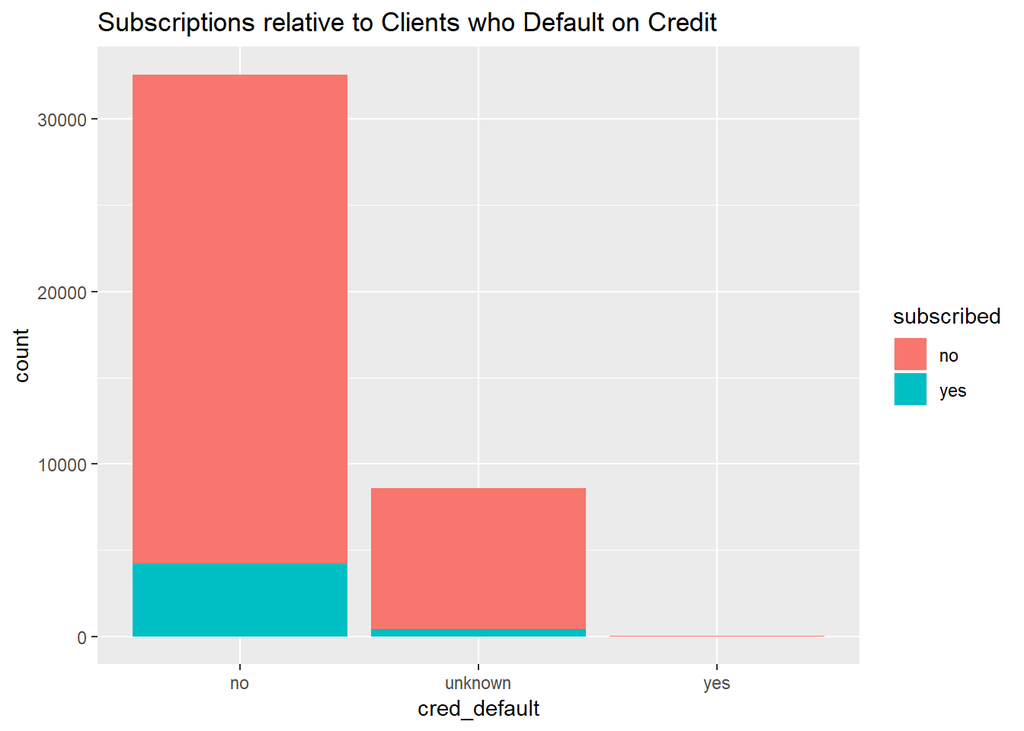

```r
ggplot(bankfull, aes(x = cred_default, fill = subscribed)) +
  geom_bar() +
  labs(title = "Subscriptions relative to Clients who Default on Credit")
```

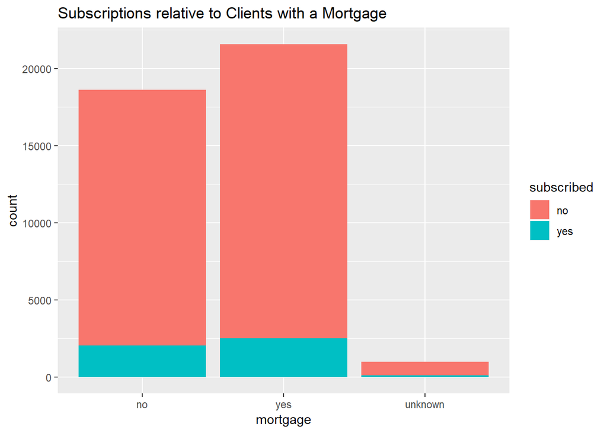

```r
ggplot(bankfull, aes(x = mortgage, fill = subscribed)) +
  geom_bar() +
  labs(title = "Subscriptions relative to Clients with a Mortgage")
```

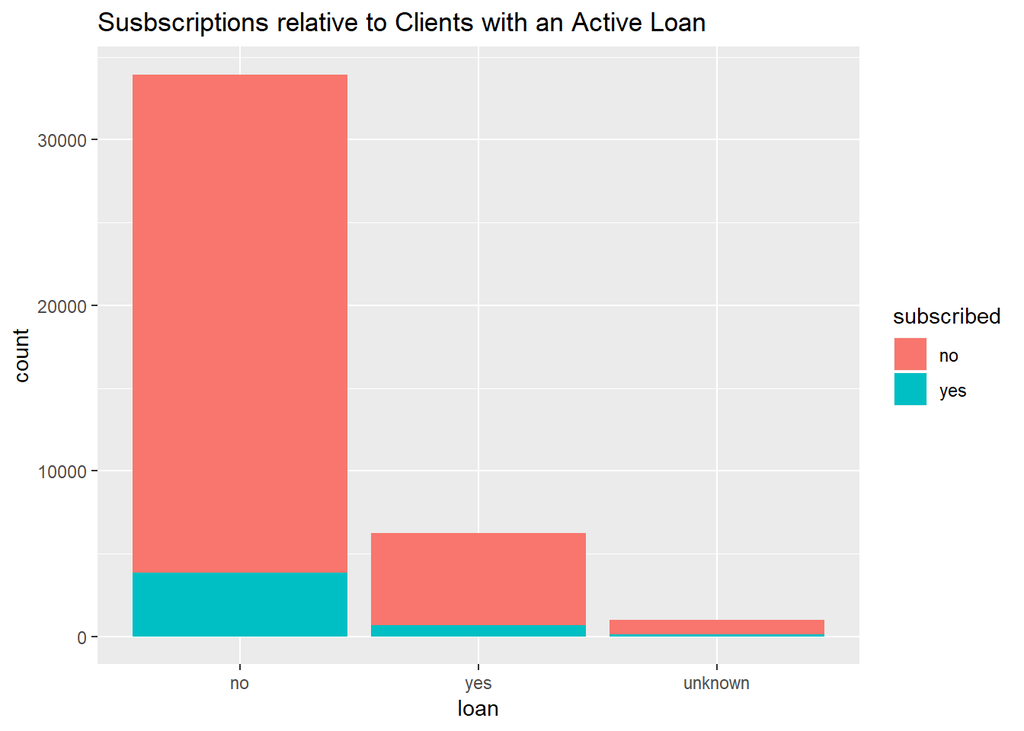

```r
ggplot(bankfull, aes(x = loan, fill = subscribed)) +
  geom_bar() +
  labs(title = "Susbscriptions relative to Clients with an Active Loan")
```

**Last Contact Data**

Last contact data will include details about the last contact with the client. Variables include type of contact, the day and month of contact, and the duration of the last contact.

Regarding last contact data, it appears customers are more inclined to subscribe when contacted via cellular compared to telephone.

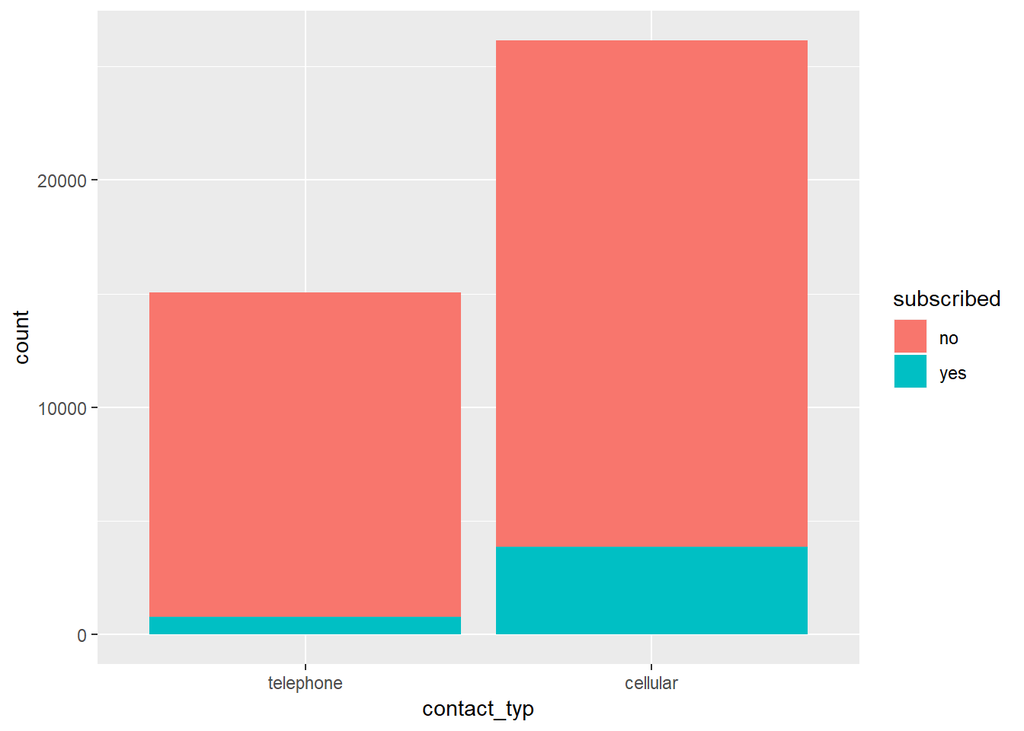

```r
ggplot(bankfull, aes(x=contact_typ, fill=subscribed)) + geom_bar()
```

```r
ctable(bankfull$contact_typ, bankfull$subscribed)
```

```
## Cross-Tabulation / Row Proportions
## Variables: contact_typ * subscribed
## Data Frame: bankfull
##
## ------------- ------------ ---------------- --------------- -----------------
##                 subscribed               no             yes             Total
##   contact_typ
##     telephone                14257 (94.77%)    787 ( 5.23%)   15044 (100.00%)
##      cellular                22291 (85.26%)   3853 (14.74%)   26144 (100.00%)
##         Total                36548 (88.73%)   4640 (11.27%)   41188 (100.00%)
## ------------- ------------ ---------------- --------------- -----------------
```

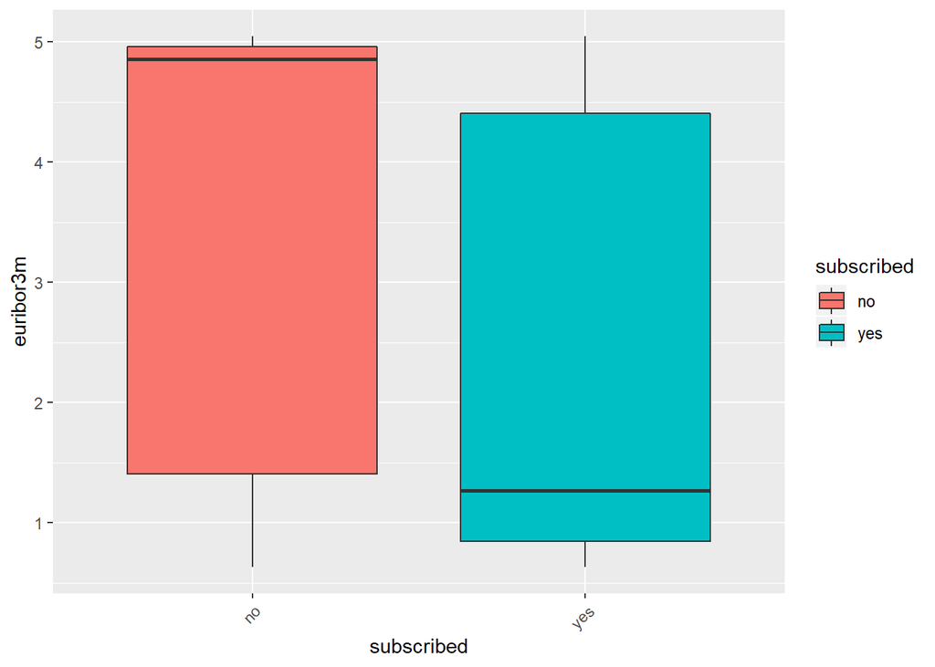

```r
ggplot(bankfull, aes(x=subscribed, y=euribor3m, fill=subscribed)) + geom_boxplot() +
  theme(axis.text.x = element_text(angle = 45, hjust = 1))
```

When looking at which month a client is most likely to subscribe, a regular bar graph by count makes it difficult. At best it looks like *May* has the most subscribers, but that doesn’t mean it’s the most likely.

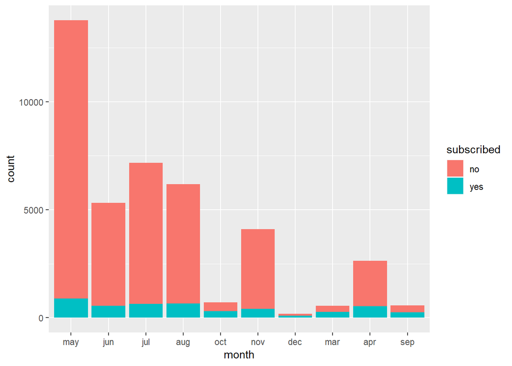

```r
ggplot(bankfull, aes(x=month, fill=subscribed)) + geom_bar()
```

If we stack each month as relative proportions we can see customers are more receptive to subscribing in *March* followed by *December* before *September*.

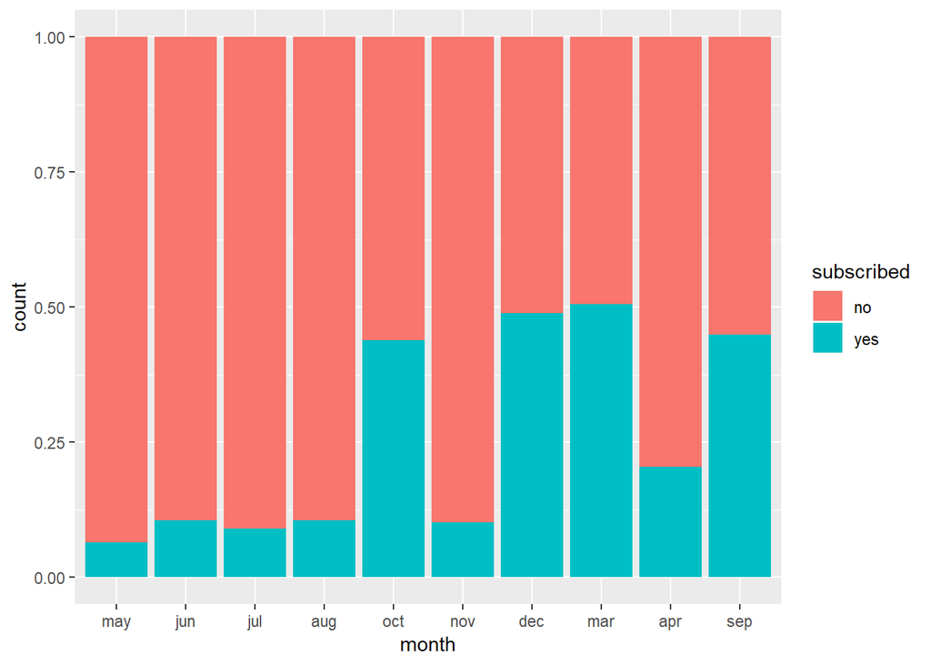

```r
ggplot(bankfull, aes(x=month, fill=subscribed)) + geom_bar(position="fill")
```

Here is a cross-tabulation of the monthly subscriptions with explicit results:

```r
ctable(bankfull$month, bankfull$subscribed)
```

```
## Cross-Tabulation / Row Proportions
## Variables: month * subscribed
## Data Frame: bankfull
##
## ------- ------------ ---------------- --------------- -----------------
##           subscribed               no             yes             Total
##   month
##     may                12883 (93.57%)    886 ( 6.43%)   13769 (100.00%)
##     jun                 4759 (89.49%)    559 (10.51%)    5318 (100.00%)
##     jul                 6525 (90.95%)    649 ( 9.05%)    7174 (100.00%)
##     aug                 5523 (89.40%)    655 (10.60%)    6178 (100.00%)
##     oct                  403 (56.13%)    315 (43.87%)     718 (100.00%)
##     nov                 3685 (89.86%)    416 (10.14%)    4101 (100.00%)
##     dec                   93 (51.10%)     89 (48.90%)     182 (100.00%)
##     mar                  270 (49.45%)    276 (50.55%)     546 (100.00%)
##     apr                 2093 (79.52%)    539 (20.48%)    2632 (100.00%)
##     sep                  314 (55.09%)    256 (44.91%)     570 (100.00%)
##   Total                36548 (88.73%)   4640 (11.27%)   41188 (100.00%)
## ------- ------------ ---------------- --------------- -----------------
```

*March* may have the most percentage of successful subscriptions but the number of client engagements is too low to be of significance. The most subscriptions do occur in *May* and other summer months, *June, July, and August* as confirmed by the frequency chart. Winter months *January* and *February* are absent from the dataset.

```r
monthsCampaign <- bankfull %>% filter(subscribed == "yes") %>% pull(month)
freq(monthsCampaign)
```

```
## Frequencies
## monthsCampaign
## Type: Factor (unordered)
##
##               Freq   % Valid   % Valid Cum.   % Total   % Total Cum.
## ----------- ------ --------- -------------- --------- --------------
##         may    886     19.09          19.09     19.09          19.09
##         jun    559     12.05          31.14     12.05          31.14
##         jul    649     13.99          45.13     13.99          45.13
##         aug    655     14.12          59.25     14.12          59.25
##         oct    315      6.79          66.03      6.79          66.03
##         nov    416      8.97          75.00      8.97          75.00
##         dec     89      1.92          76.92      1.92          76.92
##         mar    276      5.95          82.87      5.95          82.87
##         apr    539     11.62          94.48     11.62          94.48
##         sep    256      5.52         100.00      5.52         100.00
##        <NA>      0                               0.00         100.00
##       Total   4640    100.00         100.00    100.00         100.00
```

```r
ctable(bankfull$day_of_week, bankfull$subscribed)
```

```
## Cross-Tabulation / Row Proportions
## Variables: day_of_week * subscribed
## Data Frame: bankfull
##
## ------------- ------------ ---------------- --------------- -----------------
##                 subscribed               no             yes             Total
##   day_of_week
##           mon                 7667 (90.05%)    847 ( 9.95%)    8514 (100.00%)
##           tue                 7137 (88.22%)    953 (11.78%)    8090 (100.00%)
##           wed                 7185 (88.33%)    949 (11.67%)    8134 (100.00%)
##           thu                 7578 (87.88%)   1045 (12.12%)    8623 (100.00%)
##           fri                 6981 (89.19%)    846 (10.81%)    7827 (100.00%)
##         Total                36548 (88.73%)   4640 (11.27%)   41188 (100.00%)
## ------------- ------------ ---------------- --------------- -----------------
```

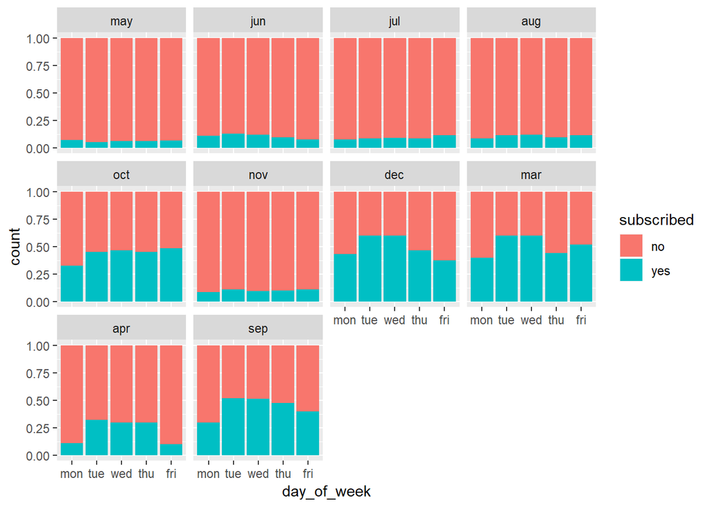

```r
ggplot(bankfull, aes(x=day_of_week, fill=subscribed)) +
  geom_bar(position="fill") +
  facet_wrap(vars(month))
```

The variable `duration` refers to the length of time in seconds spent with the customer at the last point of contact. Important note: this attribute highly affects the output target (e.g., if duration=0 then subscribed=“no”). Yet, the duration is not known before a call is performed. Also, after the end of the call *subscribed* is obviously known. Thus, this input should only be included for benchmark purposes and should be discarded if the intention is to have a realistic predictive model.

```r
descr(bankfull$duration_sec)
```

```
## Descriptive Statistics
## bankfull$duration_sec
## N: 41188
##
##                     duration_sec
## ----------------- --------------
##              Mean         258.29
##           Std.Dev         259.28
##               Min           0.00
##                Q1         102.00
##            Median         180.00
##                Q3         319.00
##               Max        4918.00
##               MAD         139.36
##               IQR         217.00
##                CV           1.00
##          Skewness           3.26
##       SE.Skewness           0.01
##          Kurtosis          20.24
##           N.Valid       41188.00
##         Pct.Valid         100.00
```

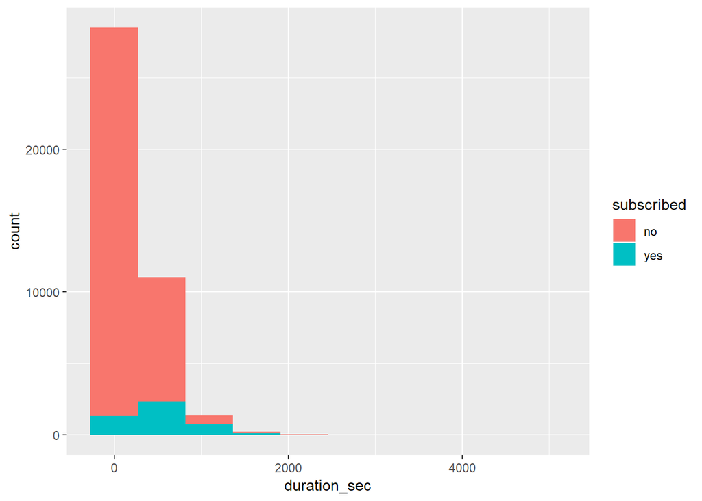

```r
ggplot(bankfull, aes(x=duration_sec, fill=subscribed)) + geom_histogram(bins=10)
```

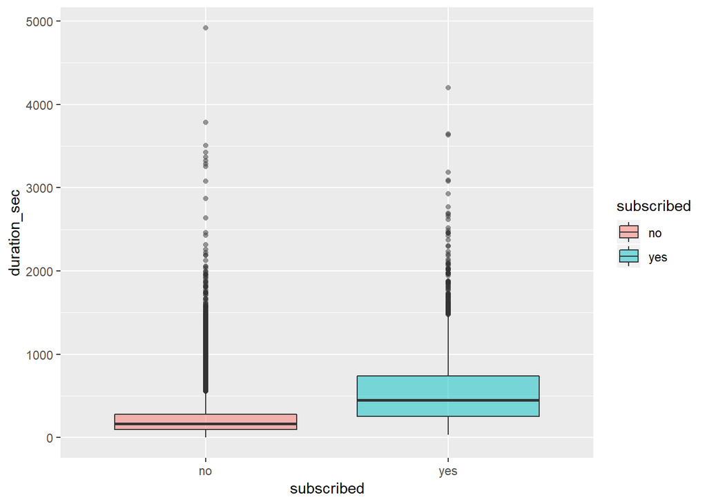

```r
ggplot(bankfull, aes(x=subscribed, y=duration_sec, fill=subscribed)) +
  geom_boxplot(outlier.shape=16, alpha=.5)
```

There’s a slight overlap in the Interquaritle Range of subscribers with the non-subscribers. That is, there’s a cut-off from the Q3 for non-subscribers and Q1 of subscribers.

```r
subscribedYES <- filter(bankfull, subscribed=="yes") %>% select(duration_sec)
descr(subscribedYES)
```

```
## Descriptive Statistics
## subscribedYES$duration_sec
## N: 4640
##
##                     duration_sec
## ----------------- --------------
##              Mean         553.19
##           Std.Dev         401.17
##               Min          37.00
##                Q1         253.00
##            Median         449.00
##                Q3         741.50
##               Max        4199.00
##               MAD         333.58
##               IQR         488.25
##                CV           0.73
##          Skewness           1.84
##       SE.Skewness           0.04
##          Kurtosis           6.31
##           N.Valid        4640.00
##         Pct.Valid         100.00
```

```r
subscribedNO <- filter(bankfull, subscribed=="no") %>% select(duration_sec)
descr(subscribedNO)
```

```
## Descriptive Statistics
## subscribedNO$duration_sec
## N: 36548
##
##                     duration_sec
## ----------------- --------------
##              Mean         220.84
##           Std.Dev         207.10
##               Min           0.00
##                Q1          95.00
##            Median         163.50
##                Q3         279.00
##               Max        4918.00
##               MAD         120.83
##               IQR         184.00
##                CV           0.94
##          Skewness           3.67
##       SE.Skewness           0.01
##          Kurtosis          31.21
##           N.Valid       36548.00
##         Pct.Valid         100.00
```

The following charts affirms the chance of a susbscription occuring decreases with each additional contact towards a customer.

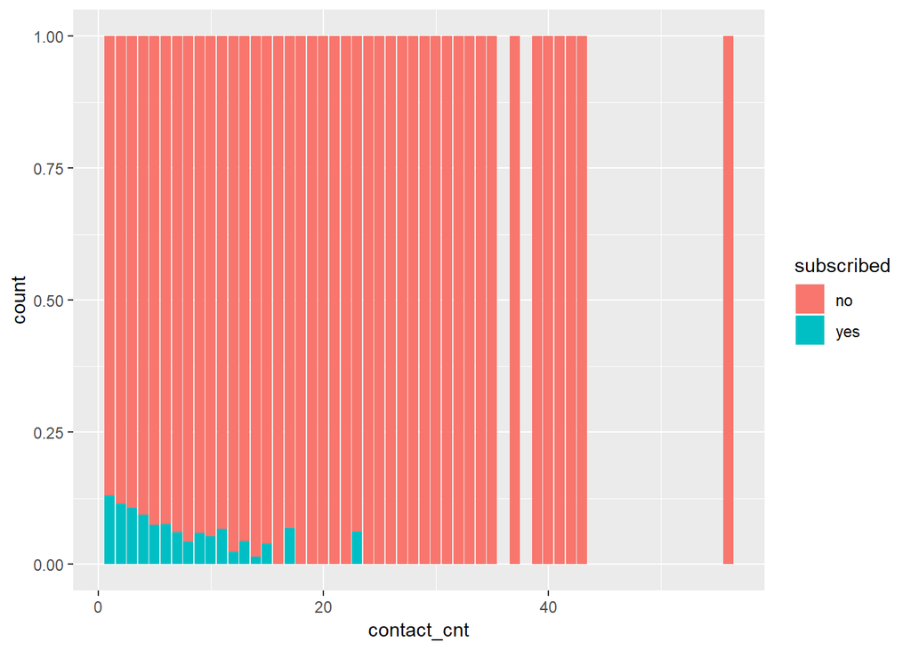

```r
ggplot(bankfull, aes(x=contact_cnt, fill=subscribed)) + geom_bar(position="fill")
```

```r
maximum_contact_cnt <- max(bankfull %>% filter(subscribed=="yes") %>%
  select(contact_cnt))
maximum_contact_cnt
```

```
## [1] 23
```

As such, the bar graph indicates clients will not subscribe if contacted by more than the maximum count value, 23.

The following density plot is for the number of days that passed from the previous campaign to the last day of contact.

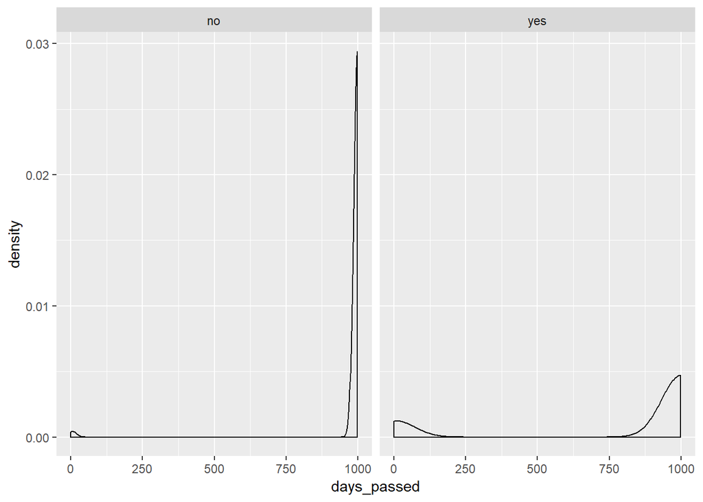

```r
ggplot(bankfull, aes(x=days_passed)) + geom_density() + facet_wrap(~subscribed)
```

```r
ctable(bankfull$days_passed, bankfull$subscribed)
```

```
## Cross-Tabulation / Row Proportions
## Variables: days_passed * subscribed
## Data Frame: bankfull
##
## ------------- ------------ ----------------- ---------------- -----------------
##                 subscribed                no              yes             Total
##   days_passed
##             0                    5 ( 33.33%)     10 ( 66.67%)      15 (100.00%)
##             1                   18 ( 69.23%)      8 ( 30.77%)      26 (100.00%)
##             2                   24 ( 39.34%)     37 ( 60.66%)      61 (100.00%)
##             3                  141 ( 32.12%)    298 ( 67.88%)     439 (100.00%)
##             4                   55 ( 46.61%)     63 ( 53.39%)     118 (100.00%)
##             5                   17 ( 36.96%)     29 ( 63.04%)      46 (100.00%)
##             6                  123 ( 29.85%)    289 ( 70.15%)     412 (100.00%)
##             7                   20 ( 33.33%)     40 ( 66.67%)      60 (100.00%)
```

[output cut: 21 more lines]

Since we know a value of 999 means a client was not previously contacted, filtering out `days_passed` = 999 should give better insight over days passed for clients that were contacted.

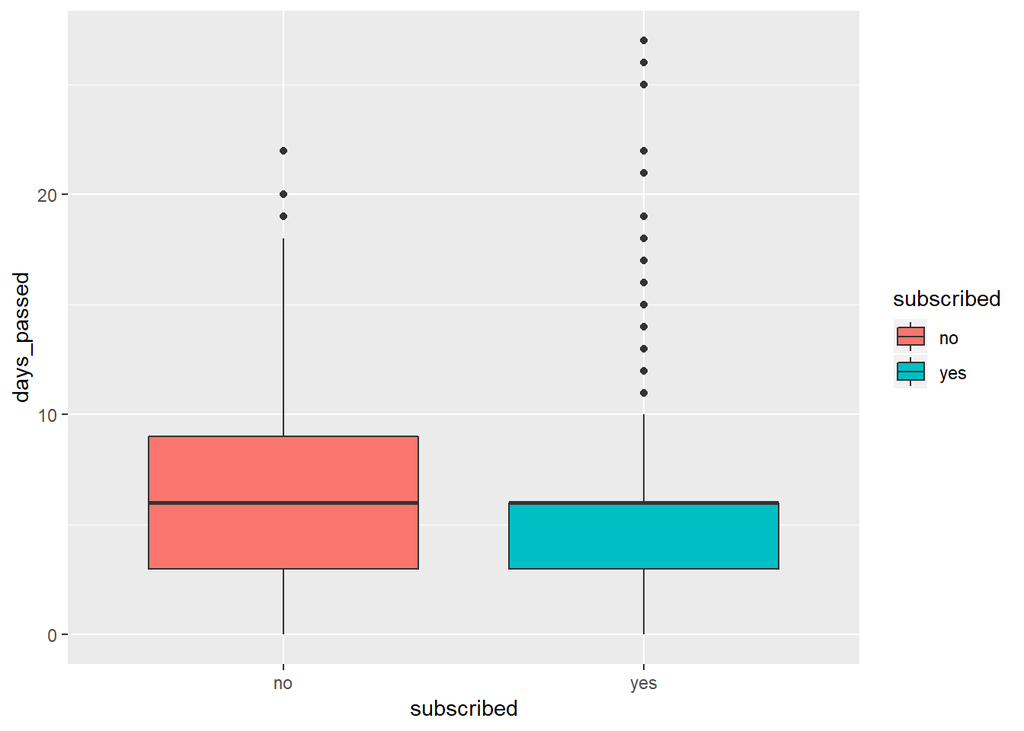

```r
daysPassedMOD <- filter(bankfull, days_passed!=999)
ggplot(daysPassedMOD, aes(x=subscribed, y=days_passed, fill=subscribed)) + geom_boxplot()
```

**Socioeconomic Data**

While generating a matrix of plots between the socioeconomic data, there looks to be a high correlation in the following 2 pairs:

- euribor3m vs employment variation rate
- euribor3m vs number employed at bank

**Chart of values from `emp_var_rate` to `num_employed`**

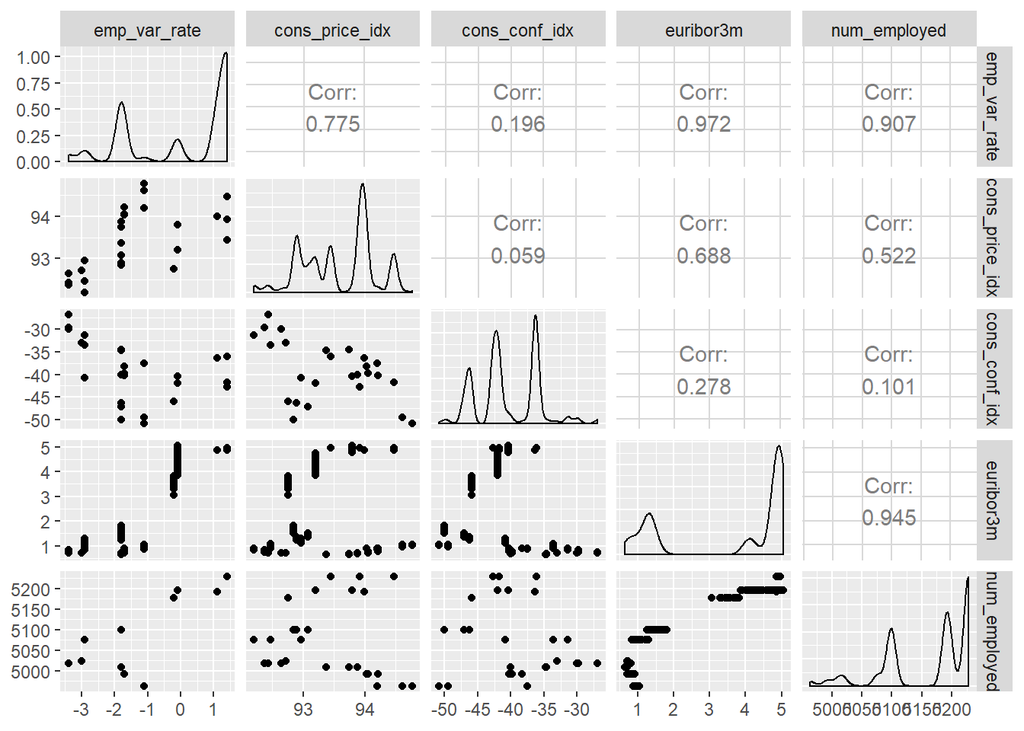

```r
ggpairs(bankfull, columns=16:20, progress=FALSE)
```

**What if I filter out the subscriptions?**

Deep correlation between Employee Variation Rate and Euribor at 3 months but doesn’t seem like it affects client subscriptions.

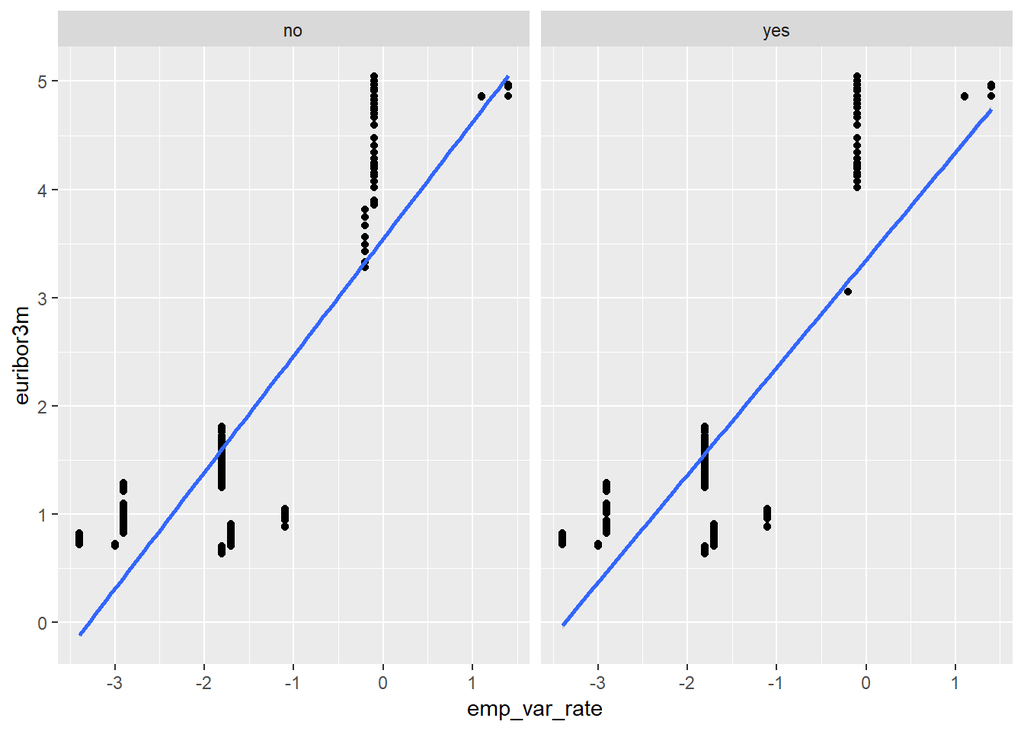

```r
ggplot(bankfull, aes(emp_var_rate, euribor3m)) + geom_point() + facet_wrap(~subscribed) + geom_smooth(method=lm)
```

Running a scatterplot for the Employment Variation Rate versus the 3 month Euribor reiterates the correlation.

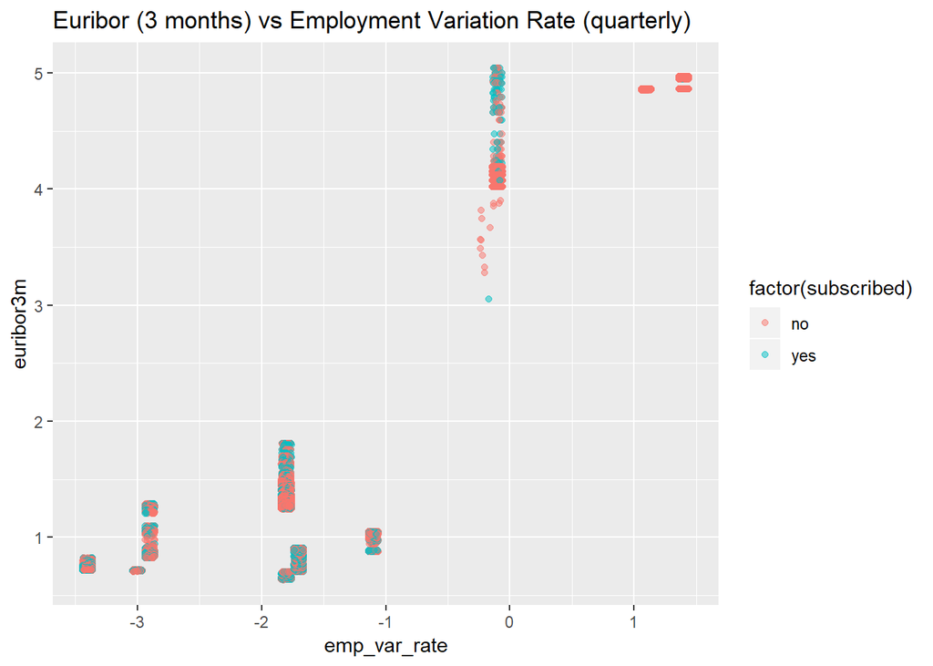

```r
ggplot(bankfull, aes(x=emp_var_rate, y=euribor3m)) +
  geom_point(aes(color = factor(subscribed)), alpha = 0.50, position="jitter") +
  labs(title = "Euribor (3 months) vs Employment Variation Rate (quarterly)")
```

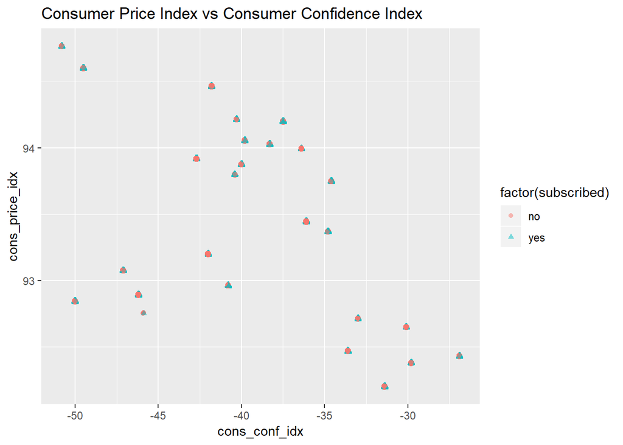

```r
ggplot(bankfull, aes(x=cons_conf_idx, y=cons_price_idx)) +
  geom_point(aes(color=factor(subscribed), shape=factor(subscribed)), alpha=0.50, position="jitter") +
  labs(title = "Consumer Price Index vs Consumer Confidence Index")
```

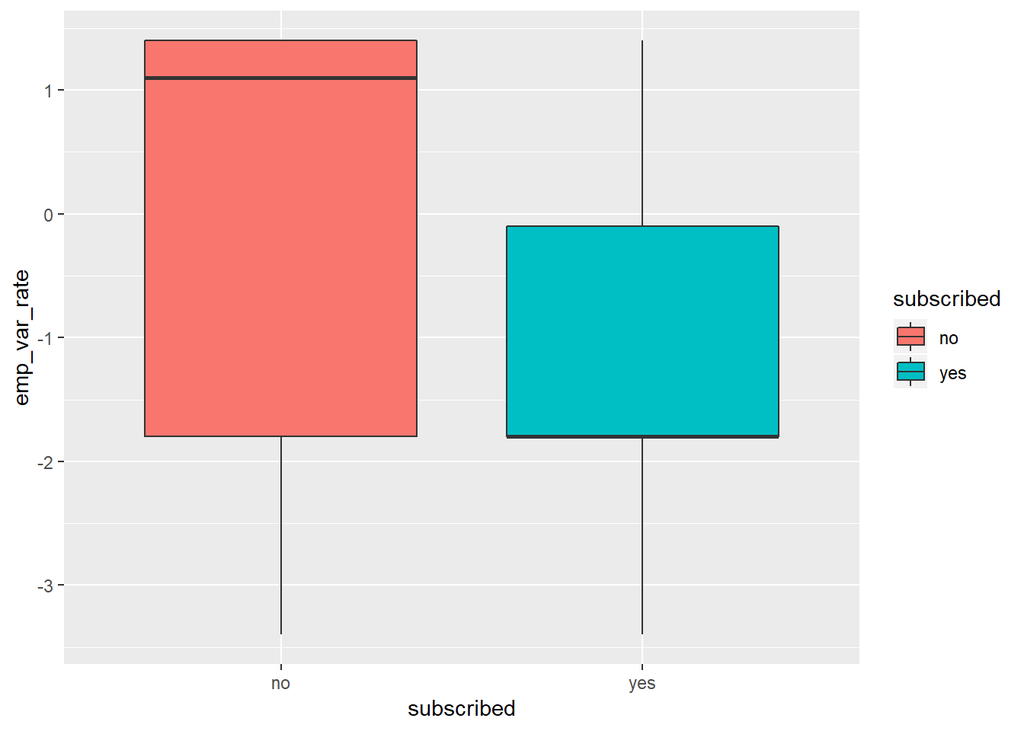

```r
ggplot(bankfull, aes(x=subscribed, y=emp_var_rate, fill=subscribed)) + geom_boxplot()
```

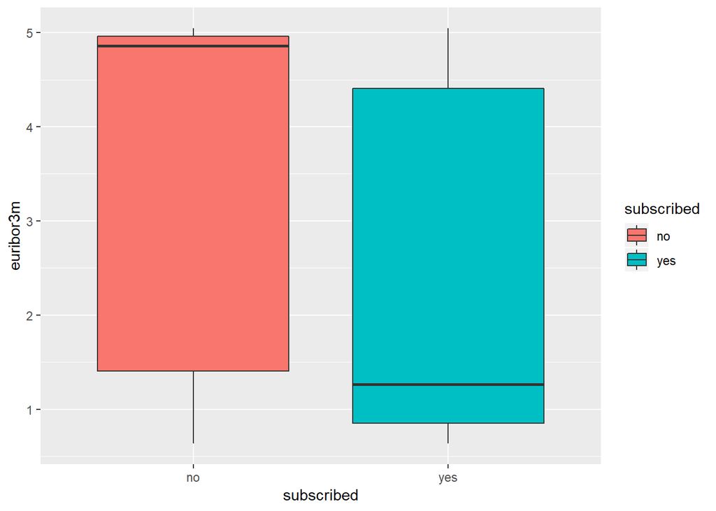

```r
ggplot(bankfull, aes(x=subscribed, y=euribor3m, fill=subscribed)) + geom_boxplot()
```

*Write the revised dataset into a cleaned-up file.*

```r
write_csv(bankfull, path="bankfull_clean.csv", col_names=TRUE)
```